# Course Project - Practical Machine Learning

Andreia Vieira

12/08/2020

## Prediction Assignment Writeup

### 1) Summay

Company are realized measurements regularly about themselves to improve their health, to find patterns in their behavior, or because they are tech geeks. In this perspective,participants were asked to perform barbell lifts correctly and incorrectly in 5 different ways. Based on this experience, the activity aims to predict the way in which new participants performed the exercises described and answer questions in the associated course questionnaire. The initial studies were based on the experience of six participants. The machine learning algorithm, which uses the class variable in the training set, is applied to the 20 test cases. The activity was developed in RStudio and published in html format.

### 2) Data

The training data for this project are available here: https://d396qusza40orc.cloudfront.net/predmachlearn/pml-training.csv

The test data are available here: https://d396qusza40orc.cloudfront.net/predmachlearn/pml-testing.csv

The data for this project come from this source: http://groupware.les.inf.puc-rio.br/har.

VELLOSO, E.; BULLING, A.; GELLERSEN, H.; UGULINO, W.; FUKS, H. Qualitative Activity Recognition of Weight Lifting Exercises. Proceedings of 4th International Conference in Cooperation with SIGCHI (Augmented Human ’13) . Stuttgart, Germany: ACM SIGCHI, 2013.

### 3) Data Loading

```r
library(caret)
#library(knitr)
library(ggplot2)
library(rpart)
#library(rpart.plot)
library(lares)
library(dplyr)
library(Hmisc)
library(corrplot)
#library(rattle)
library(randomForest)
library(gbm)
set.seed(2020)

# set the URL for the download
Train <- "http://d396qusza40orc.cloudfront.net/predmachlearn/pml-training.csv"
Validation  <- "http://d396qusza40orc.cloudfront.net/predmachlearn/pml-testing.csv"

# download the datasets
training <- read.csv(url(Train))
validation  <- read.csv(url(Validation))

str(training)
```

```
## 'data.frame':    19622 obs. of  160 variables:
##  $ X                       : int  1 2 3 4 5 6 7 8 9 10 ...
##  $ user_name               : chr  "carlitos" "carlitos" "carlitos" "carlitos" ...
##  $ raw_timestamp_part_1    : int  1323084231 1323084231 1323084231 1323084232 1323084232 1323084232 1323084232 1323084232 1323084232 1323084232 ...
##  $ raw_timestamp_part_2    : int  788290 808298 820366 120339 196328 304277 368296 440390 484323 484434 ...
##  $ cvtd_timestamp          : chr  "05/12/2011 11:23" "05/12/2011 11:23" "05/12/2011 11:23" "05/12/2011 11:23" ...
##  $ new_window              : chr  "no" "no" "no" "no" ...
##  $ num_window              : int  11 11 11 12 12 12 12 12 12 12 ...
##  $ roll_belt               : num  1.41 1.41 1.42 1.48 1.48 1.45 1.42 1.42 1.43 1.45 ...
##  $ pitch_belt              : num  8.07 8.07 8.07 8.05 8.07 8.06 8.09 8.13 8.16 8.17 ...
##  $ yaw_belt                : num  -94.4 -94.4 -94.4 -94.4 -94.4 -94.4 -94.4 -94.4 -94.4 -94.4 ...
##  $ total_accel_belt        : int  3 3 3 3 3 3 3 3 3 3 ...
##  $ kurtosis_roll_belt      : chr  "" "" "" "" ...
##  $ kurtosis_picth_belt     : chr  "" "" "" "" ...
##  $ kurtosis_yaw_belt       : chr  "" "" "" "" ...
```

[output cut: 86 more lines]

### 4) Data cleaning

```r
data_training <-training


# Variable characteristics
#str(data_training)


# remove variables that are mostly NA
data_NA    <- sapply(data_training, function(x) mean(is.na(x))) > 0.95
data_training <- data_training[, data_NA==FALSE]
dim(data_training)
```

```
## [1] 19622    93
```

```r
# values close to zero - weak correlation

data_zero <- nearZeroVar(data_training)
data_training<- data_training[, -data_zero]
dim(data_training)
```

```
## [1] 19622    59
```

```r
#remover variables init
data_training <- data_training[, -(1:5)]
dim(data_training)
```

```
## [1] 19622    54
```

```r
# split

data_split <- createDataPartition(data_training$classe, p=0.7, list=FALSE)

TrainSet <- data_training[data_split,]
TestSet  <- data_training[-data_split,]

dim(TrainSet)
```

```
## [1] 13737    54
```

```r
dim(TestSet)
```

```
## [1] 5885   54
```

```r
#Filtered variables

str(TrainSet)
```

```
## 'data.frame':    13737 obs. of  54 variables:
##  $ num_window          : int  11 12 12 12 12 12 12 12 12 12 ...
##  $ roll_belt           : num  1.41 1.48 1.45 1.42 1.43 1.43 1.42 1.42 1.45 1.48 ...
##  $ pitch_belt          : num  8.07 8.07 8.06 8.13 8.16 8.18 8.2 8.21 8.2 8.15 ...
##  $ yaw_belt            : num  -94.4 -94.4 -94.4 -94.4 -94.4 -94.4 -94.4 -94.4 -94.4 -94.4 ...
##  $ total_accel_belt    : int  3 3 3 3 3 3 3 3 3 3 ...
##  $ gyros_belt_x        : num  0.02 0.02 0.02 0.02 0.02 0.02 0.02 0.02 0 0 ...
##  $ gyros_belt_y        : num  0 0.02 0 0 0 0 0 0 0 0 ...
##  $ gyros_belt_z        : num  -0.02 -0.02 -0.02 -0.02 -0.02 -0.02 0 -0.02 0 0 ...
##  $ accel_belt_x        : int  -22 -21 -21 -22 -20 -22 -22 -22 -21 -21 ...
##  $ accel_belt_y        : int  4 2 4 4 2 2 4 4 2 4 ...
##  $ accel_belt_z        : int  22 24 21 21 24 23 21 21 22 23 ...
##  $ magnet_belt_x       : int  -7 -6 0 -2 1 -2 -3 -8 -1 0 ...
##  $ magnet_belt_y       : int  608 600 603 603 602 602 606 598 597 592 ...
##  $ magnet_belt_z       : int  -311 -302 -312 -313 -312 -319 -309 -310 -310 -305 ...
```

[output cut: 40 more lines]

### 5) - Correlation Analysis

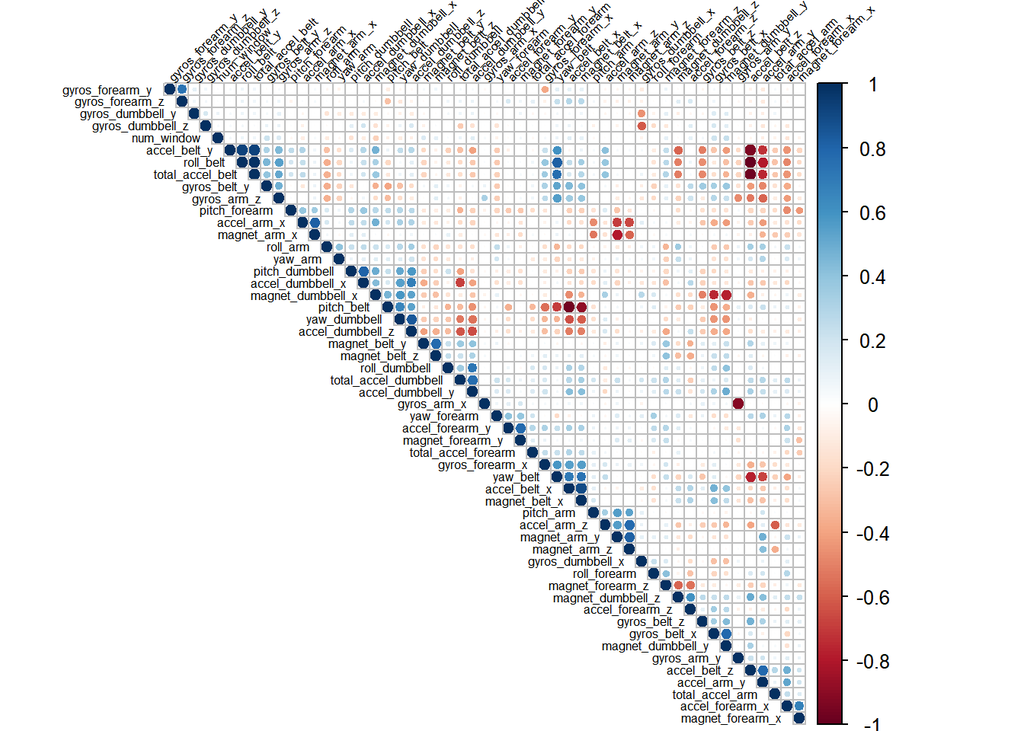

```r
#  Dataset without target variable - 53 variables
Avaiable_Correlation<-TrainSet[, -54]

# Correlations all variables
Matrix_correlation<-cor(Avaiable_Correlation)
corrplot(Matrix_correlation, type="upper", order="hclust", tl.col="black", tl.srt=45, tl.cex = 0.5)
```

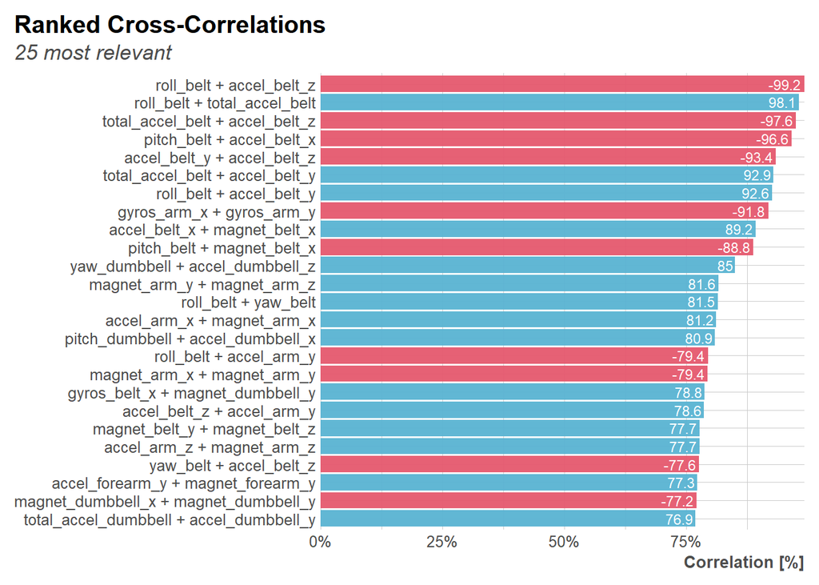

```r
#Variables that showed some high correlations - 29 variables
corr_cross(Avaiable_Correlation)
```

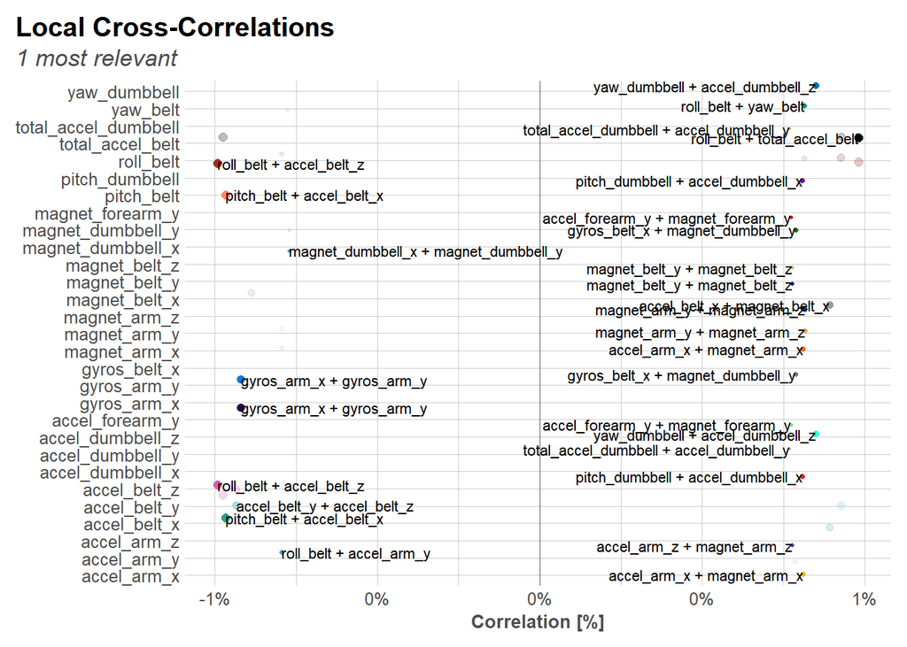

```r
corr_cross(Avaiable_Correlation, type = 2)
```

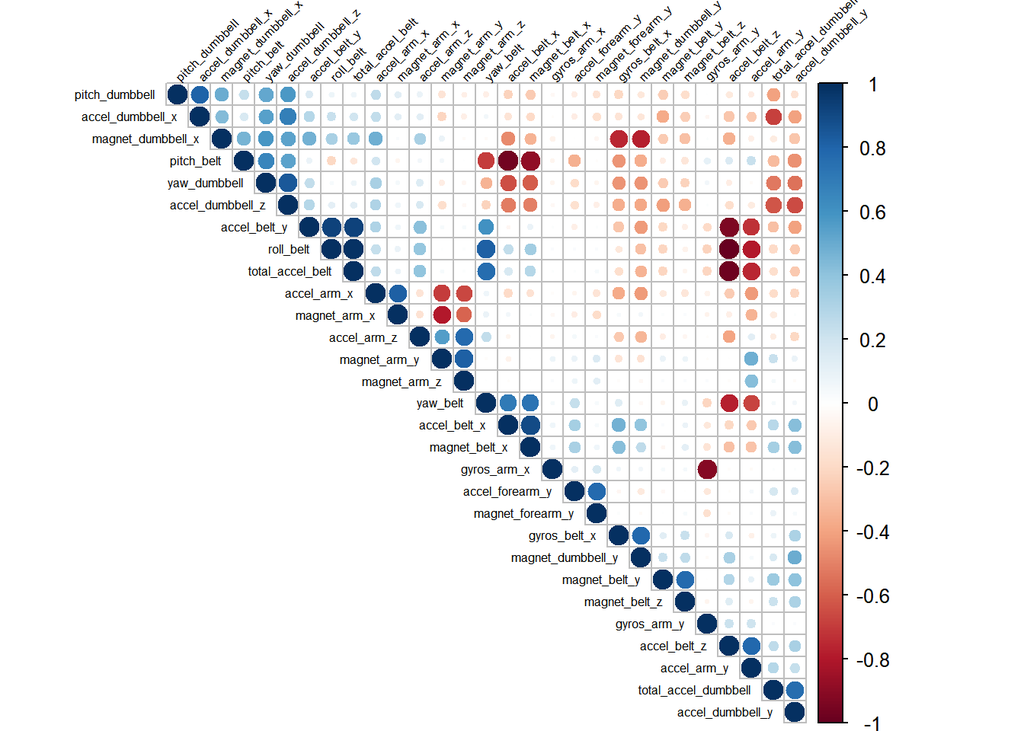

```r
variables<-corr_cross(Avaiable_Correlation, plot=FALSE)



#filter
Newdataset<-select(Avaiable_Correlation,accel_arm_z, yaw_belt, accel_forearm_y, magnet_dumbbell_x,
total_accel_dumbbell,yaw_dumbbell,magnet_arm_y,roll_belt,accel_arm_x,pitch_dumbbell,
roll_belt,magnet_arm_x,gyros_belt_x,accel_belt_z,magnet_belt_y,magnet_arm_z,accel_belt_z,
magnet_forearm_y,magnet_dumbbell_y,accel_dumbbell_y,roll_belt,roll_belt,total_accel_belt,
pitch_belt,accel_belt_y,total_accel_belt,roll_belt,gyros_arm_x,accel_belt_x,pitch_belt,
accel_dumbbell_z,magnet_arm_z,yaw_belt,magnet_arm_x,accel_dumbbell_x,accel_arm_y,magnet_arm_y,
magnet_dumbbell_y,accel_arm_y,magnet_belt_z,accel_belt_z,total_accel_belt,accel_belt_z,
accel_belt_x,accel_belt_z,accel_belt_y,accel_belt_y,gyros_arm_y,magnet_belt_x,magnet_belt_x)


# Correlations selected variables - 29 variables
Matrix_correlation<-cor(Newdataset)
corrplot(Matrix_correlation, type="upper", order="hclust", tl.col="black", tl.srt=45, tl.cex = 0.5)
```

### 6) Prediction Model Building

#### 6.1 Method: gbm and rf- training

```r
#gbm model
set.seed(2020)
model_gbm <-train(classe ~ ., method="gbm", data=TrainSet, trControl= trainControl(method= "repeatedcv", number = 5, repeats = 1), verbose = FALSE)
model_gbm$finalModel
```

```
## A gradient boosted model with multinomial loss function.
## 150 iterations were performed.
## There were 53 predictors of which 53 had non-zero influence.
```

```r
#rf model
set.seed(2021)
model_rf <- train(classe ~ ., data=TrainSet, method="rf",
                          trControl=trainControl(method="cv", number=5, verboseIter=FALSE))
model_rf$finalModel
```

```
##
## Call:
##  randomForest(x = x, y = y, mtry = param$mtry)
##                Type of random forest: classification
##                      Number of trees: 500
## No. of variables tried at each split: 27
##
##         OOB estimate of  error rate: 0.26%
## Confusion matrix:
##      A    B    C    D    E class.error
## A 3906    0    0    0    0 0.000000000
## B    9 2643    6    0    0 0.005643341
## C    0    9 2387    0    0 0.003756260
## D    0    0    8 2243    1 0.003996448
## E    0    0    0    3 2522 0.001188119
```

#### 6.2 Method: gbm and rf- test

```r
# test model gbm
predict_gbm <- predict(model_gbm, newdata=TestSet)
confMat_gbm  <- confusionMatrix(table(predict_gbm, TestSet$classe))
confMat_gbm
```

```
## Confusion Matrix and Statistics
##
##
## predict_gbm    A    B    C    D    E
##           A 1671   10    0    1    0
##           B    2 1118   12    2    0
##           C    0   10 1012    9    3
##           D    1    1    2  950    7
##           E    0    0    0    2 1072
##
## Overall Statistics
##
##                Accuracy : 0.9895
##                  95% CI : (0.9865, 0.9919)
##     No Information Rate : 0.2845
##     P-Value [Acc > NIR] : < 0.00000000000000022
##
##                   Kappa : 0.9867
##
##  Mcnemar's Test P-Value : NA
##
## Statistics by Class:
##
##                      Class: A Class: B Class: C Class: D Class: E
## Sensitivity            0.9982   0.9816   0.9864   0.9855   0.9908
## Specificity            0.9974   0.9966   0.9955   0.9978   0.9996
## Pos Pred Value         0.9935   0.9859   0.9787   0.9886   0.9981
## Neg Pred Value         0.9993   0.9956   0.9971   0.9972   0.9979
## Prevalence             0.2845   0.1935   0.1743   0.1638   0.1839
## Detection Rate         0.2839   0.1900   0.1720   0.1614   0.1822
## Detection Prevalence   0.2858   0.1927   0.1757   0.1633   0.1825
## Balanced Accuracy      0.9978   0.9891   0.9909   0.9916   0.9952
```

```r
# test model rf
predict_rf <- predict(model_rf, newdata=TestSet)
confMat_rf  <- confusionMatrix(table(predict_rf, TestSet$classe))
confMat_rf
```

```
## Confusion Matrix and Statistics
##
##
## predict_rf    A    B    C    D    E
##          A 1673    4    0    0    0
##          B    0 1132    5    0    0
##          C    0    3 1018    3    0
##          D    0    0    3  961    2
##          E    1    0    0    0 1080
##
## Overall Statistics
##
##                Accuracy : 0.9964
##                  95% CI : (0.9946, 0.9978)
##     No Information Rate : 0.2845
##     P-Value [Acc > NIR] : < 0.00000000000000022
##
##                   Kappa : 0.9955
##
##  Mcnemar's Test P-Value : NA
##
## Statistics by Class:
##
##                      Class: A Class: B Class: C Class: D Class: E
## Sensitivity            0.9994   0.9939   0.9922   0.9969   0.9982
## Specificity            0.9991   0.9989   0.9988   0.9990   0.9998
## Pos Pred Value         0.9976   0.9956   0.9941   0.9948   0.9991
## Neg Pred Value         0.9998   0.9985   0.9984   0.9994   0.9996
## Prevalence             0.2845   0.1935   0.1743   0.1638   0.1839
## Detection Rate         0.2843   0.1924   0.1730   0.1633   0.1835
## Detection Prevalence   0.2850   0.1932   0.1740   0.1641   0.1837
## Balanced Accuracy      0.9992   0.9964   0.9955   0.9979   0.9990
```

#### 6.3 Method: gbm and rf- plot

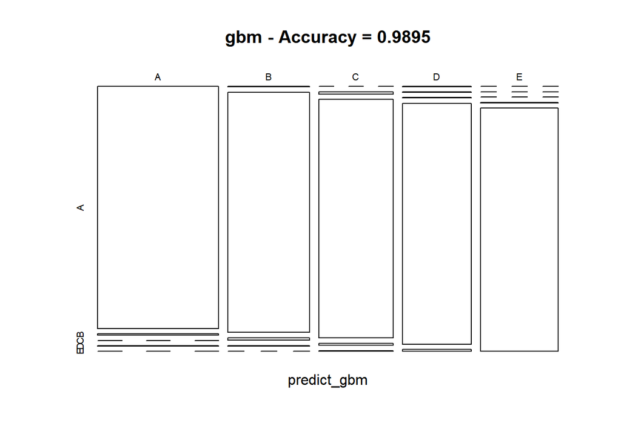

```r
# plot matrix gbm results
plot(confMat_gbm$table, col = confMat_gbm$byClass,
    main = paste("gbm - Accuracy =", round(confMat_gbm$overall['Accuracy'], 4)))
```

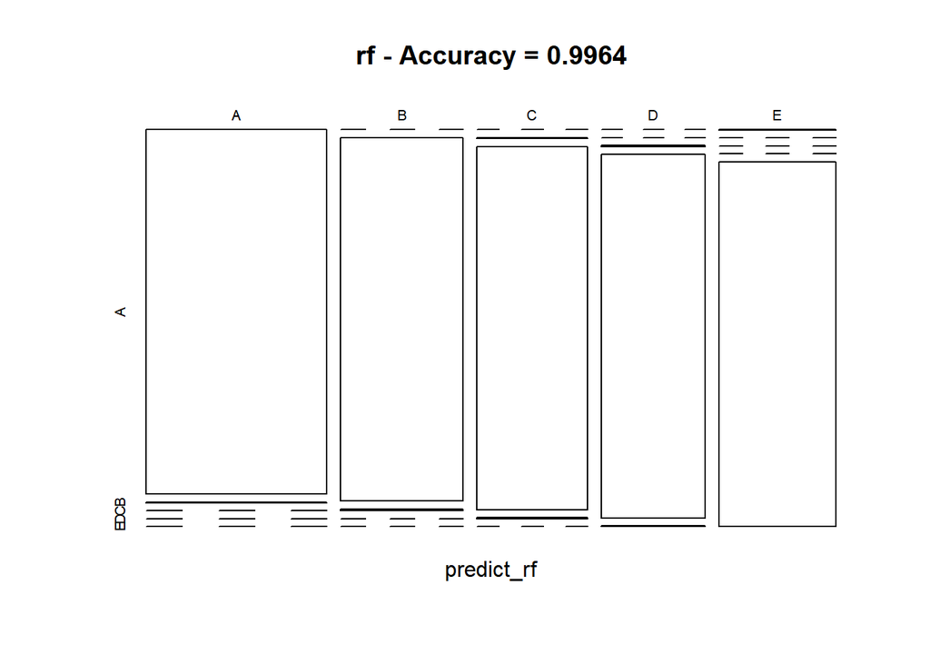

```r
# plot matrix rf results
plot(confMat_rf$table, col = confMat_rf$byClass,
    main = paste("rf - Accuracy =", round(confMat_rf$overall['Accuracy'], 4)))
```

### 7) Applying the Selected Model (best model) to the Test Data (Validation)

```r
#best result  method rf
predict_validation <- predict(model_rf, newdata=validation)
predict_validation
```

```
##  [1] B A B A A E D B A A B C B A E E A B B B
## Levels: A B C D E
```

[output not shown]